# Yulun Wu, University of Ottawa

Intro **|** Links **|** My Study **|** Hobbies **|** Contact

## Intro

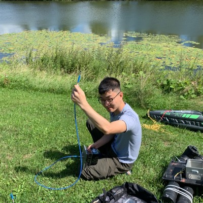

Hi! I’m a PhD student in the [Shallow Water Earth Observation Lab](https://shallowwaterlab.com/) at the University of Ottawa. I study atmospheric correction for satellite-based aquatic remote sensing over coastal and inland waters. My current goals are to deepen my understanding of radiative transfer in the ocean-atmosphere systems and collect more in-situ radiometric and water-quality data in lakes and rivers across Ontario and British Columbia, Canada.

## Links

CV  
[LinkedIn](https://www.linkedin.com/in/yulwu/)

## Modelling and Correcting for the Adjacency Effect

My PhD thesis focuses on the adjacency effect and how it affects water’s TOA radiance. The adjacency effect describes the contribution of land towards water’s colour seen from space, and I model this with a 3D Monte Carlo radiative-transfer code that I developed. This work will support satellite-derived bathymetry and remote sensing of biochemical processes in coastal areas.

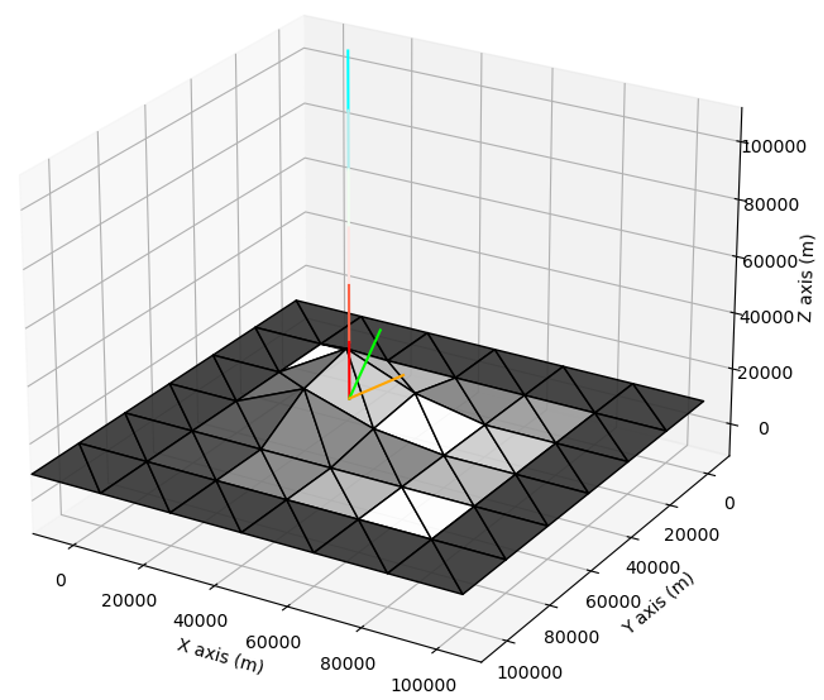

Figure 1. A photon incident on a triangulated surface. The photon moves from the blue end to the red end of the vertical line and intersects the triangulated pixel below. The green line intersecting the same point is the surface normal of the triangle. The orange line is the sampled direction from a reflection of a Lambertian surface tilted to the surface normal, it is also the new direction of propagation in the photon’s next movement.

[See my 15-min presentation at the Ocean Sciences Meeting 2022 for more details](https://youtu.be/Av-b9rl_fuU)

## Hobbies

I love playing basketball and reading science fiction in my free time.

## Contact

Email: ywu146@uottawa.ca

[figure not shown]

Shallow Water Earth Observation Lab  
Department of Geography, Environment and Geomatics  
University of Ottawa, Ottawa, ON, Canada